# NCEA data

Shan-I Lee

7/1/2017

## Cluster analysis

**Aim:** Partition student achievement data according to the decile of the school.

**Approach:** Use a numerical method to model clusters then graphical analysis to interpret and analyse clusters.

**Numerical method:** Heirarchical clustering algorithm using Euclidean distances (since data are percentages) and average linkage method.

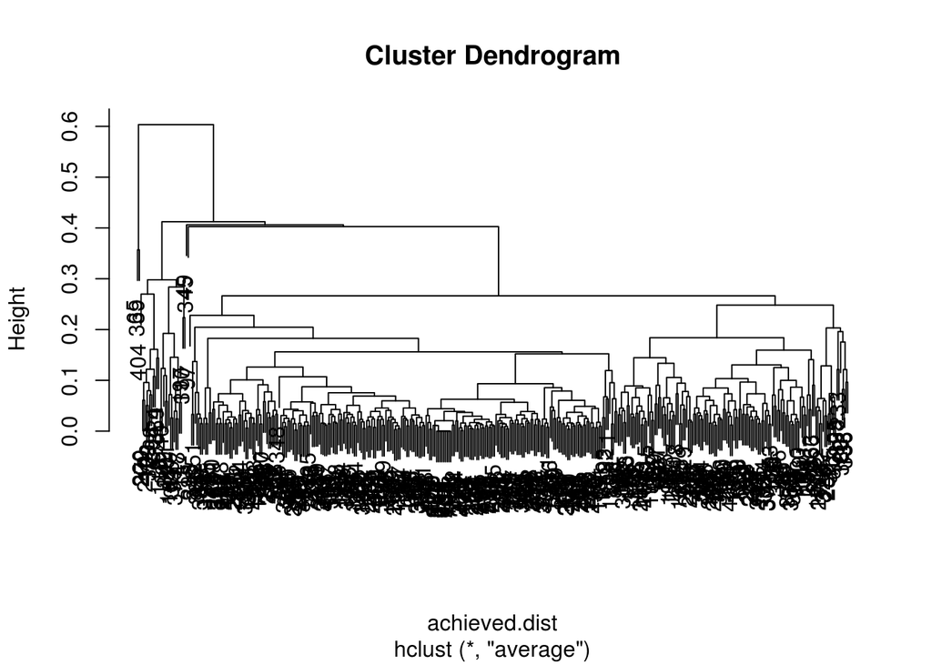

```r
# Remove obs with any NA values (Otherwise errors in hclust())
ach_narm <- achieved[complete.cases(achieved),] #407 schools left
achieved.dist <- dist(ach_narm[,2:4])
achieved.dend <- hclust(achieved.dist, method = "average")
# Dendrogram plot
plot(achieved.dend)
```

From the plot we decide to cut the dendrogram to produce 5 clusters (around height=0.4). We except 2 singleton clusters, 1 cluster w two cases, 1 large cluster (over 0.6 of cases), 1 smaller cluster.

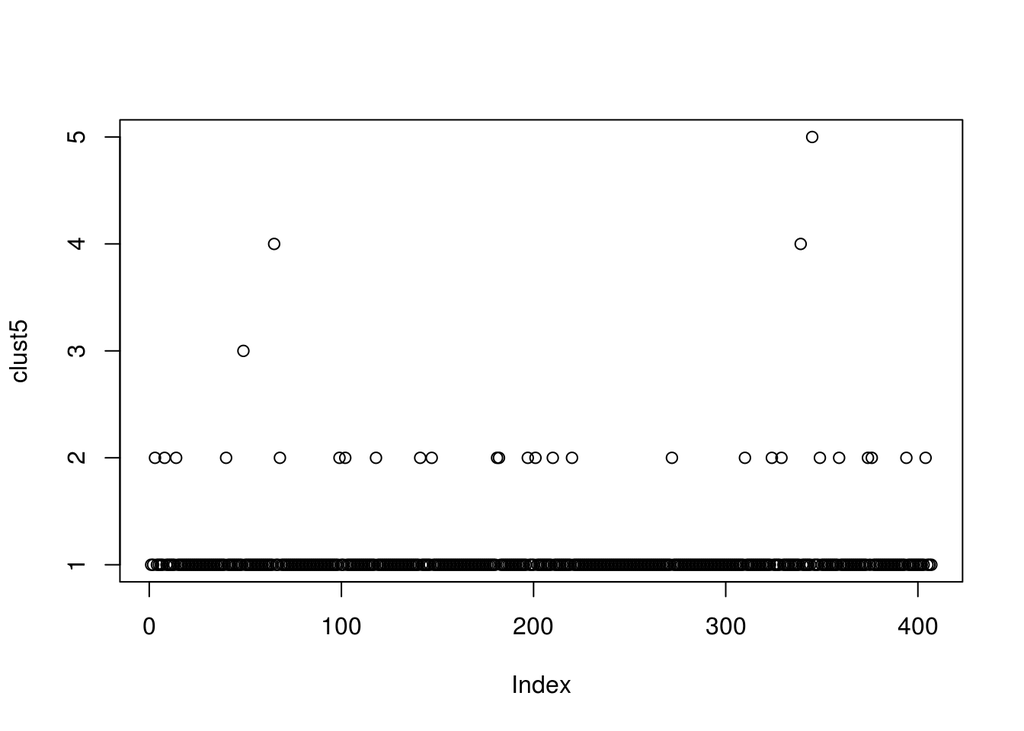

```r
clust5 <- cutree(achieved.dend, k=5)
plot(clust5) # Static R plot confirms expected size of clusters
```

The following chunks of code requires the `rggobi` and `DescribeDisplay` packages to be loaded (see `setup` chunk above). If you are in an environment that is able to run the two packages and `ggobi` then delete `eval=FALSE` from the chunck option below.

```r
# Read data into ggobi
gd <- ggobi(ach_narm)[1]
# ggobi: Parallel coord plot and scattermatrix
display(gd, "Parallel Coordinates Display")
display(gd, "Scattermatrix Display")
# Alternate highlighting each cluster yellow
glyph_color(gd)[clust5==1] <- 9 # Highlight first cluster (yellow)
glyph_color(gd)[clust5==1] <- 1 # Reset colour (purple)

# ggobi: 2D tour
display(gd, "2D Tour Display")
# Colour the two clusters pink (bigger, higher), yellow (smaller, lower), the rest (outliers) gray
glyph_color(gd)[clust5==1] <- 2
glyph_color(gd)[clust5==2] <- 9
glyph_color(gd)[clust5!=1 & clust5!=2] <- 1
```

#### Exploration using Scattermatrix and Parallel coordinate plot

Highlighting each cluster individually identified the following:

- Cluster 1 is the bigger main cluster (with generally consistent success. Not necessarily all high achievement but includes many of the 100%).
- Cluster 2 is the smaller main cluster (with relatively lower success, esp at L2. Consists of schools from the lower tail for each level). A lot of overlap between Cluster 1 and 2.
- Cluster 3 is the outlier 49 (100% L3 but lower at other levels, esp L2).
- Cluster 4 are the two schools 339 and 65 (100% L2 and 3 but low L1).
- Cluster 5 is the outlier 345 (100% at L1 and L2 but low L3).

```r
# Save plot in ggobi first (Tools, Save Display Description)
# Labels for identified points will also be saved
tour <- dd_load("2Dtour_plot")
str(tour)
# Plot coordinates and projection matrix for static view (F - need to check)
tour$plots[[1]]$params$F
ggplot(tour)
```

### Findings: NCEA data

**The two main clusters:** Apart from one school, all of the remaining schools in the smaller, lower cluster are at decile 6 or below. The smaller cluster generally consists of the lower tail of the distributions of achievement at each level, but there is a lot of overlap between the two clusters.

**The four outliers:** The 4 schools that were outliers were from decile 5 or below. None had UE at 100% but had other levels at 100%. They were identified as unusual due to inconsistencies in performance across the levels (100% at one or more levels, but unexpectedly low performance in the remaining levels).

**Univariate distns:** There appears to be a bi-modal distribution at L3 (and a very slight emergence of a bi-model distribution at L2).

### Reflections: Interactive visualisation techniques

**Scattermatrix:** Very useful to be able to color by cluster and view 1D ASH (histograms).

**PCP:** Useful for identifying outliers and view cluster patterns across vars BUT very difficult to brush/identify cases due to overplotting or when cases are similar.

**2D tour:** It was difficult to decide when to pause the tour and hence which projection showed the ‘best’ separation. The NCEA data is possibly difficult to separate visually, since the dendrogram did not indicate clear separation between the two main clusters.